# Współczynnik dzietności w wybranych regionach światata w latach 2005 - 2010

Alicja Wiączkoska

2023-02-05

## Opis bazy

Analizie poddano fragment bazy danych sporządzonej przez **Organizację Narodów Zjednoczonych**. Jest to zestawienie wskaźników dotyczących liczby żywych urodzeń w zależności od wieku matek w poszczególnych latach oraz regionach śwata.

#### Przygotowanie ramki danych

Baza została pobrana ze strony https://population.un.org/wpp/Download/Standard/CSV/. Następnie zapisano ją jako ramkę danych i usunięto zbędne fragmenty, a także zmieniono typu kolumn na `factor` tam, gdzie było to konieczne.

#### Nazwy kolumn badanej bazy

```
## 'data.frame':    162 obs. of  6 variables:
##  $ Location: Factor w/ 3 levels "Europe and Northern America",..: 3 3 3 3 3 3 3 3 3 3 ...
##  $ Time    : Factor w/ 6 levels "2005","2006",..: 1 1 1 1 1 1 1 1 1 2 ...
##  $ AgeGrp  : Factor w/ 9 levels "10-14","15-19",..: 1 2 3 4 5 6 7 8 9 1 ...
##  $ ASFR    : num  8.36 124.31 230.81 244.07 218.37 ...
##  $ PASFR   : num  0.754 11.211 20.816 22.012 19.693 ...
##  $ Births  : num  381 4974 7921 6896 5048 ...
```

Analizowana ramka danych składa się z 6 kolumn i 162 wierszy.
Poszczególne kolumny to:
- `Location` - nazwa analizowanwgo regionu,
- `Time` - lata z przedziału 2005 - 2010,
- `AgeGrp` - przedziały wiekowe kobiet: 10-14, 15-19, 20-24, 25-29, 30-34, 35-39, 40-44, 45-49, 50-54,
- `ASFR` *(Age-Specific Fertility Rate)* - współczynnik dzietności (według wieku) obliczany ze wzoru:
$$\frac{liczba\ dzieci\ urodzonych\ przez\ matki\
w\ podanym\ przedziale\ wiekowym}{liczba\ kobiet\ w\ podanym\
przedziale\ wiekowym} \cdot 1000,$$
- `PASFR` *(Percent Age-specific Fertility Rate)* - procentowy współczynnik dzietności (według wieku) obliczany dla poszczególnych lat ze wzoru:
$$\frac{liczba\ dzieci\ urodzonych\ przez\
matki\ w\ podanym\ przedziale\ wiekowym}{liczba\ wszystkich\ dzieci\
urodzonych\ w\ danym\ roku} \cdot 100\%$$
*(`PASFR` dla poszczególnego regionu w danym roku sumuje się do 100),*
- `Births` - liczba żywych dzieci (w tysiącach) urodzonych przez matki w danym przedziale wiekowym.
Jakć można odczyta ze struktury ramki, kolumny `Location`, `Time` oraz `AgeGrp` są typu `factor`, a pozostałe typu `numeric`.

## Podstawowe statystki

```
##                             Location    Time        AgeGrp        ASFR
##  Europe and Northern America    :54   2005:27   10-14  :18   Min.   :  0.012
##  Latin America and the Caribbean:54   2006:27   15-19  :18   1st Qu.:  3.814
##  Sub-Saharan Africa             :54   2007:27   20-24  :18   Median : 45.202
##                                       2008:27   25-29  :18   Mean   : 69.649
##                                       2009:27   30-34  :18   3rd Qu.:107.414
##                                       2010:27   35-39  :18   Max.   :244.073
##                                                 (Other):54
##      PASFR             Births
##  Min.   : 0.0030   Min.   :   0.468
##  1st Qu.: 0.7285   1st Qu.: 104.810
##  Median :10.0250   Median :1461.544
##  Mean   :11.1111   Mean   :2047.122
##  3rd Qu.:20.8212   3rd Qu.:3164.995
##  Max.   :29.4140   Max.   :8798.518
##
```

Jak można odczytać, W kolumnie `Location` znajdują się 3 regiony: Europe and Northern America, Latin America and the Caribbean, Sub-Saharan Africa. Do każdego z nich są przyporządkowane dokładnie 54 wiersze.

Natomiast najmniejszą wartością wkaźnika `PASFR` jest 0.003% przyjmowane dla przedziału wiekowego50-54 w 2010 roku w regionie Europe and Northern America. Największy procentowy udział liczyby urodzeń wynosi 29.414% osiągnięty w grupie wiekowej 25-29 obliczany na terenie Europe and Northern America w 2010 roku. Średnia wartość występująca w kolumnie `PASFR` to 11.1111296, a mediana 10.025.

## Zależności między danymi

#### Wskaźnik PASFR a grupa wiekowa matek w zależności od regionu

Na podstawie zgromadzonych danych stworzono wykres zależności procentowej liczby urodzeń od grupy wiekowej matek z wyróżnieniem obszarów ich zamieszania. Każda z linii odpowiada informacjom pochodzącym z jednego roku.

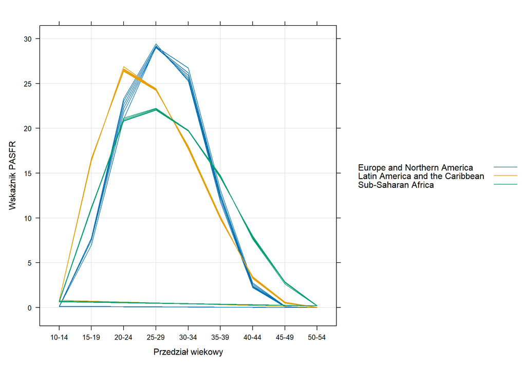

Można z niego odczytać, że wskaźnik PASFR jest dla Europy i Północnej Ameryki jest najwyższy w przedziale wiekowym 25-29 lat i niewiele niższy w grupie 30-34 lat. Z kolei W Ameryce Łacińsiej i na Karaibach dominujący wiek matek to 20-24 r.ż i tuż za nim 25-29. W Afryce Subsaharyjskiej jest podna sytuacja, lecz w odwrotnwj kolejności. Można też wywnioskować że procentowo więcej kobiet rodzi dziecko po 40 r.ż. W Afryce niż w pozostałtych regionach.

#### Wskaźnik ASFR a grupa wiekowa matek w zależności od regionu

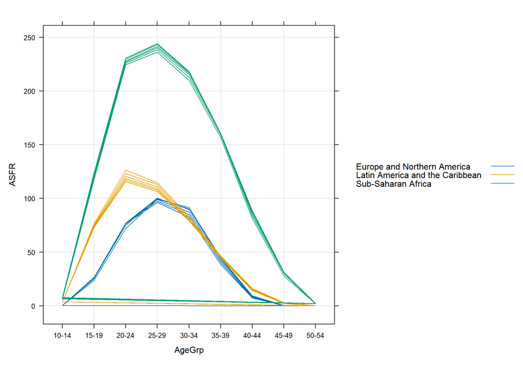

#### Liczba urodzeń w poszczególnych regionach

| Region | Suma urodzeń w latach 2005-2010 (w tys.) |
| --- | --- |
| Europe and Northern America | 75160.08 |
| Latin America and the Caribbean | 65743.01 |
| Sub-Saharan Africa | 190730.66 |

Z powyższej ramki danych stworzonej na podstawie analizowanej bazy łatwo można zauważyć, że ponad dwukrotnie więcej dzieci urodziło się w Sub-Saharan Africa niż w pozostałych regioach. Najmniej urodzeń odnotowano w sumie w regionie Latin America and the Caribbean, lecz liczba ta jest porównywalna z wynikiem dla Europe and Northern America. Poniższy wykres słupkowy ukazujący zmiany liczby urodzeń na przestrzeni lat w badanych regionach również obrazuje te tendencje.

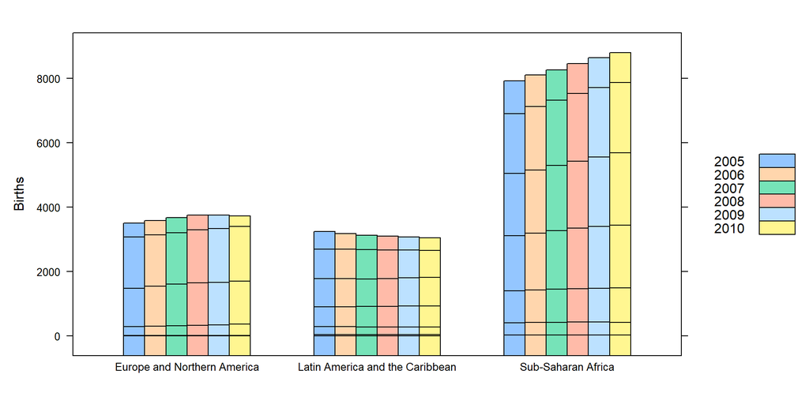

#### Ogólna Liczba urodzeń w poszczególnych grupach wiekowych

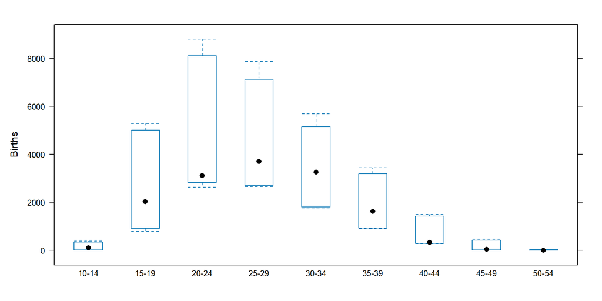

Z Powyższego wykresu odczytać można nie tylko uśrednioną liczbę urodzeń w każdej z grup wiekowych, ale też odchylenia od tej wartości. Możemy zauważyć że liczba urodzeń na początku i końcu okresu rozrodczego nie zmieniała się zbytno w zależności od czasu lub regionu. Możemy za to dostrzec duże różnice w dzietności kobiet w wieku 20-29 lat.

#### Histogramy

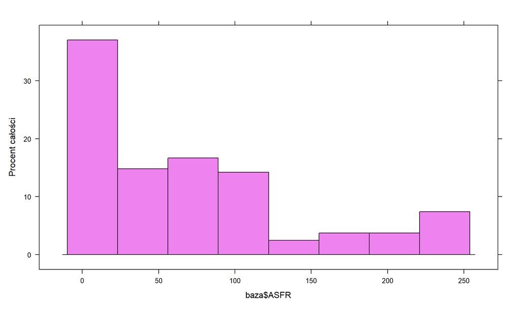

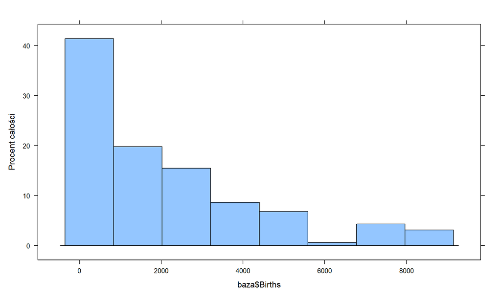